# Data validation example

Published

October 1, 2025

Modified

October 20, 2026

# Background

This page provides a simple example that visualizes the results of a GitHub Actions workflow when downloading daily chlorophyll-a (Chla) data from ERDDAP within territorial waters of US states bordering the Gulf of Mexico. Data validation is performed across pixels of the raster product within these waters, as well as for the average values per state. Validation results are summarized in reports based on user-defined conditional statements.

**Note**

You can find the R script for this analysis linked on the right side of this page.

Given the lag in data availability for the nesdisVHNSQchlaDaily Chla product (9 days), the data accessed in this example will be accessed from 2 weeks prior (i.e., 2026-10-06).

This example process involves:

1. Approximating territorial waters by buffering a spatial layer of state boundaries
2. Access the Chla data for the region of interest
3. Masking the Chla data to territorial state waters in GoM
4. Calculating mean Chla values per state
5. Validating pixel-level and state-level Chla data to check for issues
6. Generate reports from data validation

# Report output

## Report for pixel-level data

Pointblank Validation

[2026-10-20|10:41:03] data frame Gulf state daily Chl-a valuesWARN 0.01 STOP 0.25 NOTIFY 0.05

|  |  | STEP | COLUMNS | VALUES | TBL | EVAL | UNITS | PASS | FAIL | W | S | N | EXT |
| --- | --- | --- | --- | --- | --- | --- | --- | --- | --- | --- | --- | --- | --- |
|  | 1 | `col_vals_not_null()` | `▮``chla` | — |  | ✓ | `29504` | `574` `0.01945` | `28930` `0.98055` | ● | ● | ● |  |
|  | 2 | `col_vals_between()` | `▮``chla` | `[0.001, 100]` |  | ✓ | `29504` | `29504` `1` | `0` `0` | ○ | ○ | ○ | — |
|  | 3 | `col_vals_lt()` | `▮``chla` | `30` |  | ✓ | `29504` | `29472` `0.99` | `32` `0.01` | ○ | ○ | ○ |  |

2026-10-20 10:41:03 UTC < 1 s 2026-10-20 10:41:04 UTC

## Report for state-level data

Pointblank Validation

[2026-10-20|10:41:04] data frame Gulf state means for daily Chl-a dataWARN 0.20 STOP 0.25 NOTIFY 0.20

|  |  | STEP | COLUMNS | VALUES | TBL | EVAL | UNITS | PASS | FAIL | W | S | N | EXT |
| --- | --- | --- | --- | --- | --- | --- | --- | --- | --- | --- | --- | --- | --- |
|  | 1 | `col_vals_not_null()` | `▮``chla` | — |  | ✓ | `5` | `5` `1` | `0` `0` | ○ | ○ | ○ | — |
|  | 2 | `col_vals_between()` | `▮``chla` | `[2, 20]` |  | ✓ | `5` | `4` `0.8` | `1` `0.2` | ● | ● | ● |  |
|  | 3 | `col_vals_lt()` | `▮``chla` | `20` |  | ✓ | `5` | `4` `0.8` | `1` `0.2` | ● | ● | ● |  |

2026-10-20 10:41:04 UTC < 1 s 2026-10-20 10:41:05 UTC

# Maps of chl-a data

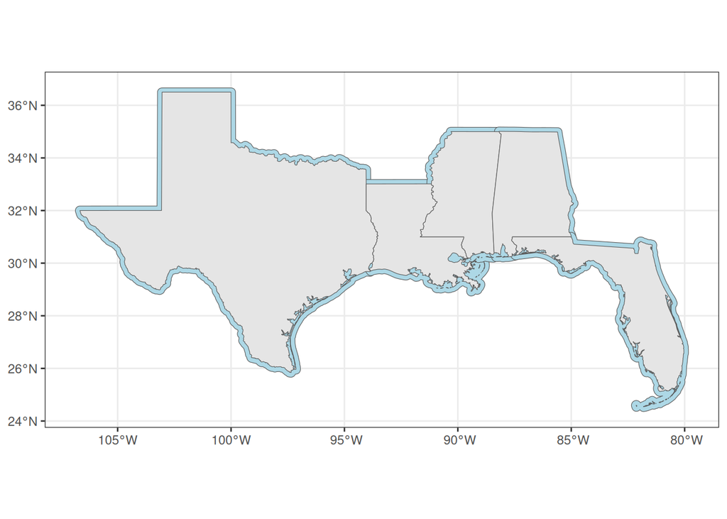

Figure 1: Boundaries of states and territorial waters (out to 12 nm) for states bordering the Gulf of Mexico.

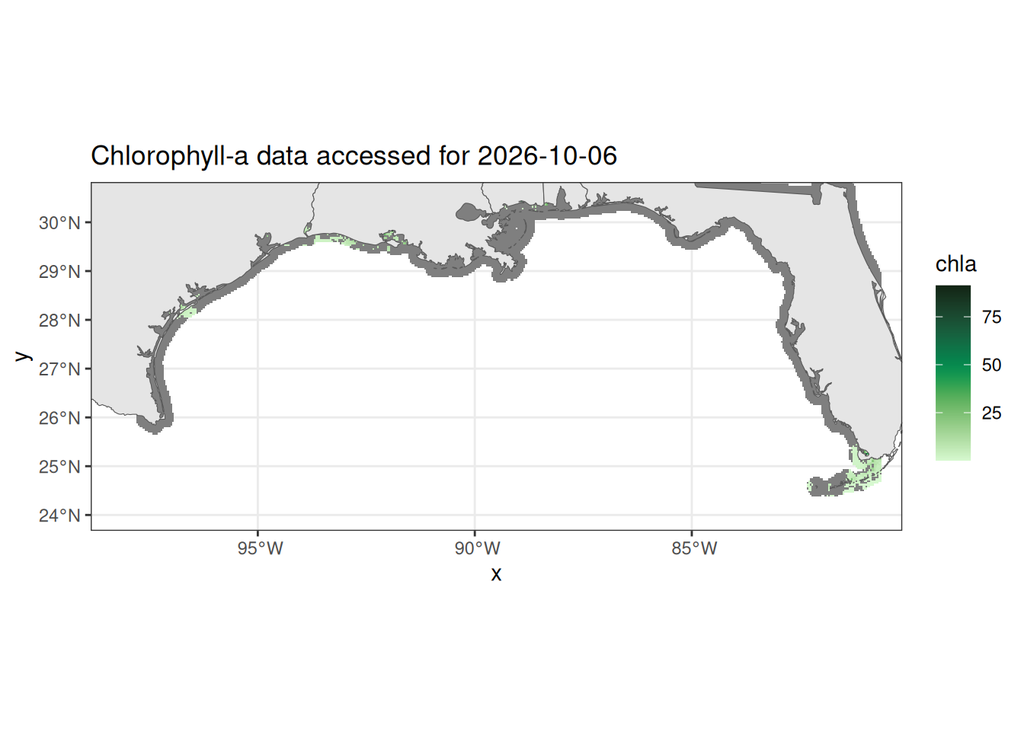

Figure 2: Masked pixels of chlorophyll-a ERDDAP product within territorial waters. Gray values denote missing values for this dataset.

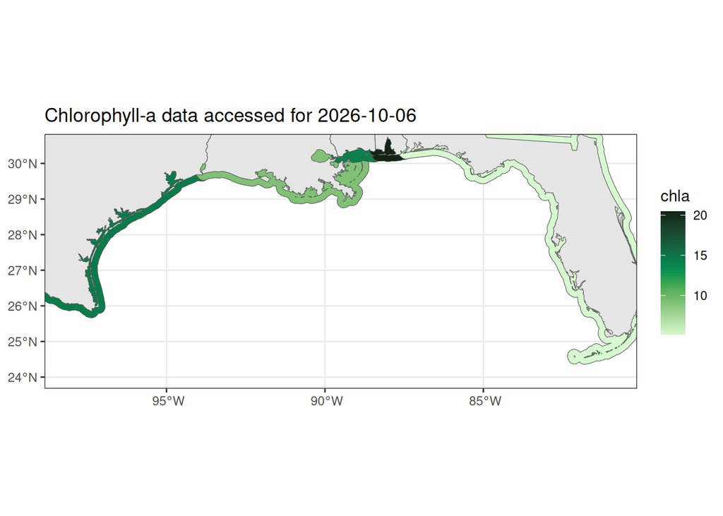

Figure 3: Mean chlorophyll-a per Gulf state within territorial waters.

Back to top